# Peer-graded Assignment: Course Project 1

Daniel Imholz

Before we begin, let’s load the packages we will be using in this analysis.

```r
library(ggplot2)
library(plyr)
library(dplyr)
library(tidyr)
```

## Loading and preprocessing the data

Let’s now load the data, assuming we are already in the correct working directory. Part of the pre-processing for this data will include transforming the items in the **date** column into Date objects.

```r
activity <- read.csv('activity.csv')
activity <- transform(activity, date = as.Date(date, format = '%Y-%m-%d'))
head(activity)
```

```
##   steps       date interval
## 1    NA 2012-10-01        0
## 2    NA 2012-10-01        5
## 3    NA 2012-10-01       10
## 4    NA 2012-10-01       15
## 5    NA 2012-10-01       20
## 6    NA 2012-10-01       25
```

## What is mean total number of steps taken per day?

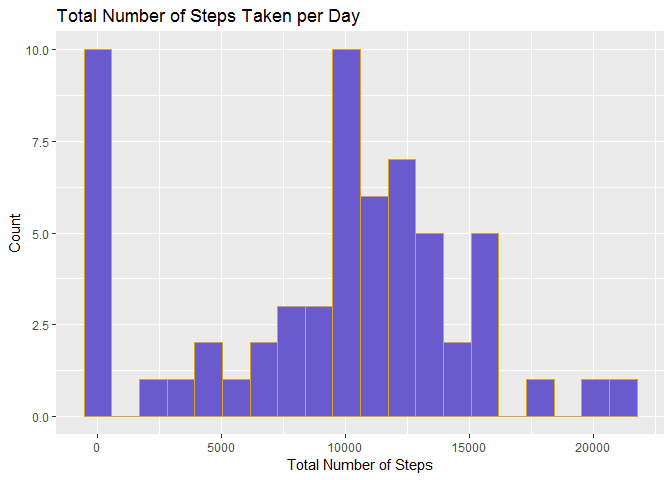

```r
total_steps <- activity %>%
  group_by(date) %>%
  summarise(n_steps = sum(steps, na.rm = TRUE))

ggplot(total_steps, aes(n_steps)) +
  geom_histogram(bins = 20, fill = 'slateblue', col = 'goldenrod') +
  xlab('Total Number of Steps') +
  ylab('Count') +
  ggtitle('Total Number of Steps Taken per Day')
```

The mean of the total number of steps taken per day is 9354.23 steps.  
The median of the total number of steps taken per day is 10395 steps.

## What is the average daily activity pattern?

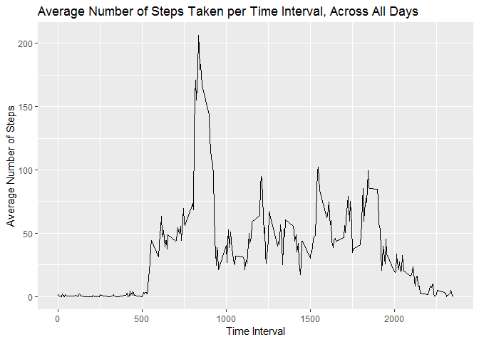

```r
by_int <- activity %>%
  group_by(interval) %>%
  summarise(m_steps = mean(steps, na.rm = TRUE))

ggplot(by_int, aes(interval, m_steps)) +
  geom_line() +
  xlab('Time Interval') +
  ylab('Average Number of Steps') +
  ggtitle('Average Number of Steps Taken per Time Interval, Across All Days')
```

The 5-minute interval where **interval** = 835 contains the maximum number of steps.

## Imputing missing values

We noticed there are some missing values in our data set, 2304 to be exact. Let’s impute these missing values using the floor of the daily *mean* for the corresponding 5-minute time interval. We’ll use the newly imputed data to create a histogram as we did earlier, and make note of any differences.

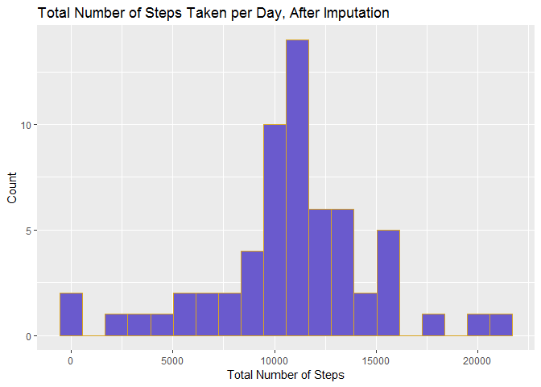

```r
by_int_floors <- activity %>%
  group_by(interval) %>%
  mutate(f_mean = mean(steps, na.rm = TRUE) %>%
              floor())

by_int_floors$imputed <- apply(by_int_floors,1, function(x) {
    x[1] <- ifelse(is.na(x[1]), x[4], x[1])
  }) %>%
  as.numeric()

activity_imp <- by_int_floors %>%
  dplyr::select(imputed, date, interval) %>%
  group_by(date)
total_imp <- activity_imp %>%
  summarise(imp_n_steps = sum(imputed))

ggplot(total_imp, aes(imp_n_steps)) +
  geom_histogram(bins = 20, fill = 'slateblue', col = 'goldenrod') +
  xlab('Total Number of Steps') +
  ylab('Count') +
  ggtitle('Total Number of Steps Taken per Day, After Imputation')
```

After imputation, the mean of the total number of steps taken per day is 10749.77 steps, compared to a mean of 9354.23 before imputation.  
After imputation, the median of the total number of steps taken per day is 10641 steps, compared to a median of 10395 before imputation.

## Are there differences in activity patterns between weekdays and weekends?

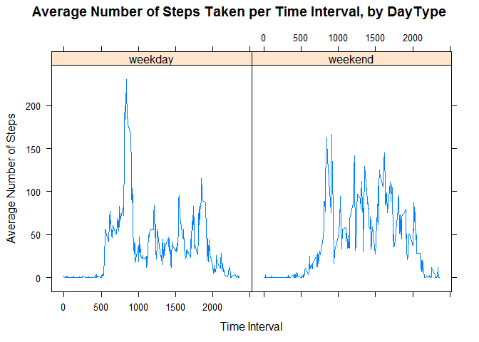

```r
library(lattice)
daynames <- weekdays(activity_imp$date)
activity_imp$daytype <- ifelse(daynames %in% c('Saturday','Sunday'), 'weekend','weekday') %>%
  as.factor()
by_int_imp <- activity_imp %>%
  group_by(daytype,interval) %>%
  summarise(mean_steps = mean(imputed))
xyplot(mean_steps ~ interval | daytype, data = by_int_imp,
       type = 'l',
       xlab = 'Time Interval',
       ylab = 'Average Number of Steps',
       main = 'Average Number of Steps Taken per Time Interval, by DayType')
```